# Linked Lists

*CSCI 1933 – Introduction to Algorithms and Data Structures*  
Adriana Picoral

## Array-based List

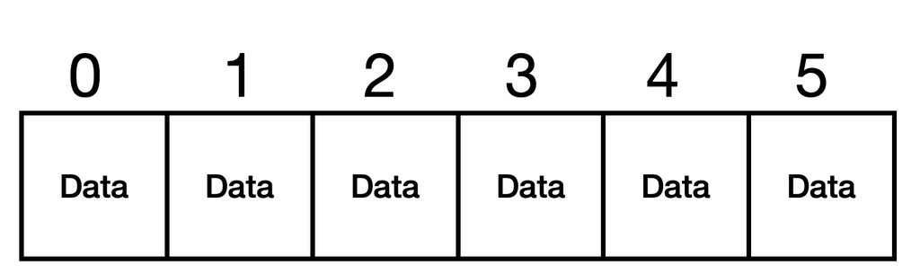

## Array-based List

Elements are stored in contiguous memory (issue of allocation)

|  | Front of List | Middle of List | End of List |
| --- | --- | --- | --- |
| get | O(1) | O(1) | O(1) |
| set | O(1) | O(1) | O(1) |
| insert | O(n) | O(n) | O(1) |
| remove | O(n) | O(n) | O(1) |

- random access (access through an index) is fast
- insert/remove something – shift everything else

## Linked lists

A linked list is a chain of nodes, where each node contains:

- data - the actual value you’re storing (like arrays)
- a pointer/reference - the address of the next node in the chain

No need for contiguous memory allocation (nodes can be scattered anywhere in memory)

## Linked List

- dynamic structure, can grow and shrink as needed (no allocation needed)
- elements are arranged in a linear sequence
- implemented through nodes – each node has a reference to the next node

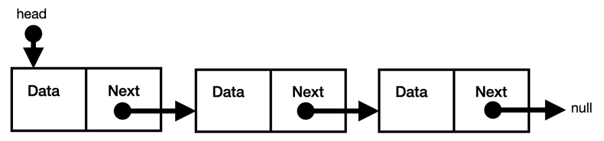

## Nodes

To create a linked list:

- a class of **self-referential** objects
- each object of the class contains a reference to an object of the same class
- convention is to name the class `Node`

Write a class in Java called `Node` that has two instance variables: data (any type), and a reference to another node.

Write the constructor method, and a set and get method for each instance variable.

## Generics

- Generic Data – what is it?
- Why generics rather than `Object`?
  - Flexibility and re-usability and strict type checking
  - Detect errors early – compile time
- Generic typing allows an attribute’s type to be specified and type-checked at compile-time using a single class definition
- Effectively, the actual type of a generic typed attribute within an object is determined at at variable definition and object creation

## Generic Node class

Write:

- a constructor that takes in `data` (type `T`)
- getters for both instance variables – `getData` and `getNext`
- setters for both instance variables – `setData` and `setNext`

```java
public class Node<T> {
    private T data;
    private Node<T> next;

}
```

Submit your `Node.java` file to [gradescope](https://www.gradescope.com/courses/1234179/assignments/7773636/)

## Solution

```java
public class Node<T> {
    private T data;
    private Node<T> next;

    // constructor
    public Node(T data) {
        this.data = data;
        next = null;
    }

    // setters
    public void setNext(Node<T> next) {
        this.next = next;
    }

    public void setData(T data) {
        this.data = data;
    }

    // getters
    public Node<T> getNext() {
        return next;
    }

    public T getData() {
        return data;
    }

}
```

## `LinkedList` class

- What instance variables do you need?

## `LinkedList` class

A linked list has a head (reference to a `Node`)

## `LinkedList` set up and constructor

```java
public class LinkedList<T> {
    private Node<T> head;

    // constructor
    public LinkedList() {
        head = null;
    }

}
```

## Methods

- What methods do you need to implement?

## Methods

- Insertion
- Search
- Deletion

A `toString()` method to test our code

## `addNode(Node<T> node)` method

Write a `addNode(Node<T> node)`

- What are the options of implementation for insertion?
- What are the advantages and disadvantages of each?

## Insert at end of list

How can we improve on this?

```java
public void addNode(Node<T> node) {
  if (head == null) head = node;
  else {
    Node<T> currNode = head;
    while (currNode.getNext() != null) {
      currNode = currNode.getNext();
    }
    currNode.setNext(node);
  }
}
```

## `toString()` method

Before we move on to other types of insert, lets create a `toString()` method to test our list insertion.

Write a `toString()` method that traverses the entire list

- Concatenate values

## `toString()` solution

```java
  @Override
  public String toString() {
  String result = "";
  Node<T> currNode = head;
  while (currNode != null) {
    result += currNode.getData() + " ";
    currNode = currNode.getNext();
  }
  return result;
}
```

## Gradescope Submission

Submit your `Node.java` (previously implemented) and `LinkedList.java` files to [gradescope](https://www.gradescope.com/courses/1234179/assignments/7773869)

Methods in `LinkedList.java` the autograder will test:

- `addNode(Node<T> node)` that adds a node at the end of the list
- `toString()`
- `isEmpty()` returns `true` if list is empty (no nodes), false otherwise
- `length()` returns an integer representing number of nodes in the list (should be `O(1)`)

## Other insertion methods?

Our insert method has to traverse the entire list to insert a new node.

How can we improve on insertion time?

## Insert at the beggining of list

```java
public void push(Node<T> node) {
  if (head == null) head = node;
  else {
    node.setNext(head);
    head = node;
  }
}
```

## `search()` method

- Similar to `toString()`

## `search()` solution

```java
public boolean search(T data) {
  Node<T> currNode = head;
  while (currNode != null) {
    if (currNode.getData().equals(data)) {
      return true;
    }
    currNode = currNode.getNext();
  }
  return false;
}
```

## Linear search – complexity

What we have implemented is an unsorted linked list – how many comparisons does it required to find a target element?

In the worst case, each node must be examined once, resulting in `O(n)` complexity – `n` is the number of elements in the list.

## Delete node

Removing a node takes a few more steps:

- Find the node to remove (if present, can find it through index or matching data), look ahead for the next node, adjust reference for the previous node
- How to remove head?

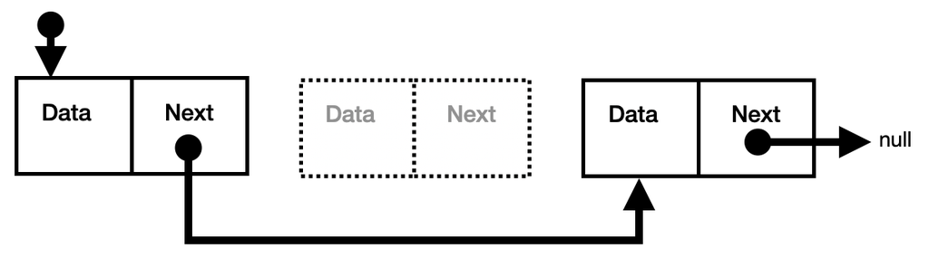

## Search matching data and remove

```java
public Node<T> remove(T data) {
  Node<T> currNode = head;
  Node<T> previous = null;
  while (currNode != null) {
    if (currNode.getData().equals(data)) {
      if (previous != null) {
        previous.setNext(currNode.getNext());
      } else {
        head = head.getNext();
      }
      return currNode;
    } else {
      previous = currNode;
      currNode = currNode.getNext();
    }
  }
  return null;
}
```

## Remove first element of the list

```java
public Node<T> pop() {
  Node<T> node = null;
  if (head != null) {
    node = head;
    head = head.getNext();
  }
  return node;
}
```

## Remove Nth node

```java
public Node<T> pop(int n) {
  if (n >= 0 && n < length) {
    Node<T> current = head;
    Node<T> previous = null;
    for (int i = 0; i < n; i++) {
      previous = current;
      current = current.getNext();
    }
    if (previous == null) return pop();
    else previous.setNext(current.getNext());
    length--;
    return current;
  }
  return null;

}
```

## Runtime of LinkedList

[output not shown]

## Other types of linked list

We just implemented a singly linked list

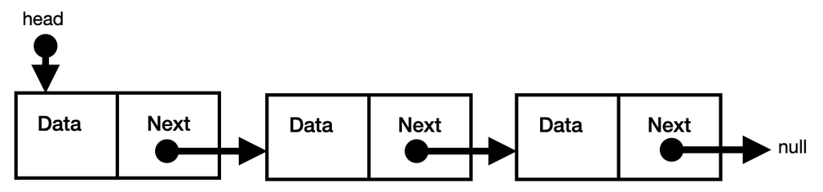

Doubly linked list:

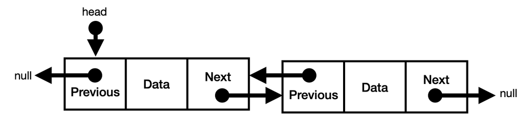

## Other types of linked list

Circular linked list:

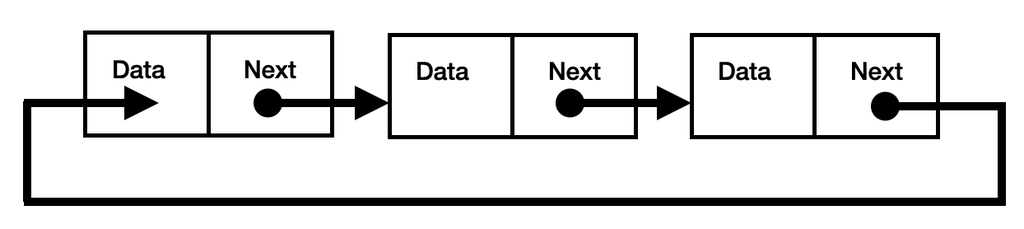

## Recursion

Many linked list functions can be nicely implemented with recursion.

```java
public Node<T> search(Node<T> node, T value) {
  if (node == null) { // base case
    return null;
  }
  if (node.getData().equals(value)) {
    return node; // found node with matching value
  }
  // search next
  return search(node.getNext(), value);

}

public Node<T> search(T value) {
  // traverse all nodes, return the first
  // node that data equals value argument
  return search(head, value);
}
```

## Comparable

Node.java

```java
public class Node<T extends Comparable<T>> implements Comparable<Node<T>> {
    private T data;
    private Node<T> next;

    public Node(T data) {
        this.data = data;
        next = null;
    }

    public T getData() {
        return data;
    }

    public Node<T> getNext() {
        return next;
    }

    public void setData(T data) {
        this.data = data;
    }

    public void setNext(Node<T> next) {
        this.next = next;
    }


    public int compareTo(Node<T> o) {
        if (this == o) {
            return 0;
        }

        if (o == null) {
            return -1;
        }

        Node<T> aNode = (Node<T>) o;
        return this.data.compareTo(aNode.getData());
    }
}
```

## Comparable

LinkedList.java

```java
public class LinkedList<T extends Comparable<T>> {
    public Node<T> head;
    public Node<T> tail;
    private int length;

    public LinkedList(Node<T> node) {
        head = node;
        tail = node;
        length++;
    }

    public void addNode(Node<T> node) {
        tail.setNext(node);
        tail = node;
        length++;
    }

    public int length() {
        return length;
    }

    public String toString() {
        String message = "";
        Node<T> current = head;
        while (current != null) {
            message += current.getData() + " ";
            current = current.getNext();
        }
        return message;
    }

    public Node<T> search(T value) {
        // traverse all nodes, return the first
        // node that data equals value argument
        Node<T> current = head;
        while (current != null) {
            if (current.getData().equals(value)) {
                return current;
            }
            current = current.getNext();
        }
        // no node with value T, return null
        return null;
    }

    public void remove(Node<T> node) {
        // remove head?
        if (head == node) {
            head = head.getNext();
        }
        // remove matching object
        Node<T> current = head;
        Node<T> previous = null;
        while (current != null) {
            // check if objects are the same
            if (current == node) {
                previous.setNext(current.getNext());
                length--;
            }
            previous = current;
            current = current.getNext();
        }

    }

    public void remove(T value) {
        // remove first node with data equals value
        // remove head?
        if (head.getData().equals(value)) {
            head = head.getNext();
        }
        // remove matching object
        Node<T> current = head;
        Node<T> previous = null;
        while (current != null) {
            // check if objects are the same
            if (current.getData().equals(value)) {
                previous.setNext(current.getNext());
                length--;
            }
            previous = current;
            current = current.getNext();
        }
    }

    public void remove(int position) {
        // remove node at Nth position
        // remove first node with data equals value
        // remove head?
        if (position == 0) {
            head = head.getNext();
        }
        // remove matching object
        Node<T> current = head;
        Node<T> previous = null;
        int counter = 1;
        while (current != null) {
            // check if objects are the same
            if (counter == position) {
                previous.setNext(current.getNext());
                length--;
            }
            previous = current;
            current = current.getNext();
            counter++;
        }
    }

    public void sort() {
        // lazy bubble sort
        for (int i=0; i < length; i++) {
            Node<T> current = head;
            while (current != null) {
                //System.out.println(current.getData() + " " + current.getNext().getData() + " " + current.compareTo(current.getNext()));
                if (current.compareTo(current.getNext()) > 0) {
                    T temp = current.getData();
                    current.setData(current.getNext().getData());
                    current.getNext().setData(temp);
                }
                current = current.getNext();
            }
        }
    }
}
```

## Use and test LinkedList

```java
public class UseList {
    public static void main(String[] args) {
        Node<String> node = new Node<>("tomato");
        LinkedList<String> list = new LinkedList<>(new Node<>("apple"));
        list.addNode(new Node<>("kiwi"));
        list.addNode(node);
        list.addNode(new Node<>("banana"));
        list.addNode(new Node<>("pineapple"));
        System.out.println(list.length());
        System.out.println(list);
        System.out.println(list.search("pear"));
        list.remove(node);

        list.addNode(new Node<>("pear"));
        list.addNode(new Node<>("orange"));
        list.addNode(new Node<>("plum"));
        list.addNode(new Node<>("tomato"));
        list.addNode(new Node<>("lychee"));

        System.out.println(list);
        list.sort();
        System.out.println(list);
    }
}
```

## `java.util.LinkedList` Class

[java.util.LinkedList](https://docs.oracle.com/javase/8/docs/api/java/util/LinkedList.html)

- Doubly-linked list implementation of the List and Deque interfaces

## Linked Lists: Pros and Cons

Some Pros:

- easy add and delete (no moving/copying values over to keep index order)
- no need to pre-specify length (use only the space that is needed)

Some Cons:

- no random access so must “link” through nodes to get to desired location in list
- sorted linked list pales over sorted array for lookup (binary search not an option)

## Looking Back

- The “list” data abstraction can be implemented as an array or linked list
- Which Implementation might be better? Why?